# Analysing Ultrasound Tongue Imaging data using (M)FPCA and GAMM – Testing with random effects

Author

Affiliation

Nathalie Elsässer

Acoustics Research Institute,  
Austrian Academy of Sciences, Vienna

Published

August 26, 2025

```r
# data processing and plotting
library(tidyverse)
library(plotly)
library(rticulate)
# GAMs
library(mgcv)
library(itsadug)
# FPCA
library(funData)
library(MFPCA)
# install.packages("devtools")
# devtools::install_github("uasolo/landmarkregUtils")
library(landmarkregUtils)
library(abind)
# LMER
library(lme4)
library(emmeans)
# plotting
library(RColorBrewer)
library(gridExtra)
source("polar_utils.R")
# convert Umlaute to ascii
library(berryFunctions)
```

```r
rhotic_data_static <- readRDS("../data/RDS/rhotic_data_static15.rds") %>% mutate(target = convertUmlaut(target))
items <- read.table("../data/itemsv.txt", header = T, sep = "\t")
group <- read.table("../data/participant_group.txt", header = T, sep = "\t")

static_items <- merge(merge(rhotic_data_static, items, by = "target"), group, by = "participant") %>% plyr::arrange(clip_id,knot)
```

# 1 stressed vs unstressed uvular rhotics

In this script I will ask the following question:

Is the tongue position during the articulation of uvular rhotics different depending on if the rhotics appear in a stressed or in an unstressed syllable?

Hypothesis: The tongue dorsum is higher and the tongue shape is overall steeper in stressed than in unstressed syllables.

Disclaimer: This is just an example. If we do not find any differences, it’s fine :-)

```r
uvular_static <- subset(static_items, group == "u") %>% mutate(stress = as.factor(stress))
```

```r
str(uvular_static)
```

```
'data.frame':   22792 obs. of  29 variables:
 $ participant        : chr  "vp004" "vp004" "vp004" "vp004" ...
 $ target             : chr  "Einrichtung" "Einrichtung" "Einrichtung" "Einrichtung" ...
 $ filename           : Factor w/ 29 levels "vp004_1_bp1_knot1",..: 1 1 1 1 1 1 1 1 1 1 ...
 $ date_time          : chr  "11.02.2025 17:37:40" "11.02.2025 17:37:40" "11.02.2025 17:37:40" "11.02.2025 17:37:40" ...
 $ knot               : num  0 1 2 3 4 5 6 7 8 9 ...
 $ x_mean             : num  -51.7 -56.5 -56.1 -50.7 -41 ...
 $ y_mean             : num  -31.61 -20.732 -8.919 0.623 6.622 ...
 $ prompt             : chr  "Danke Einrichtung" "Danke Einrichtung" "Danke Einrichtung" "Danke Einrichtung" ...
 $ knot_label         : chr  "Vallecula" "Root_1" "Root_2" "Body_1" ...
 $ clip_id            : chr  "vp004_1_bp1_knot1_1" "vp004_1_bp1_knot1_1" "vp004_1_bp1_knot1_1" "vp004_1_bp1_knot1_1" ...
 $ frame_id           : int  58 58 58 58 58 58 58 58 58 58 ...
 $ x_mean_z           : num  -0.946 -1.207 -1.182 -0.892 -0.376 ...
 $ y_mean_z           : num  -2.178 -1.404 -0.563 0.117 0.544 ...
 $ cat                : chr  "initial_unstressed_vorne" "initial_unstressed_vorne" "initial_unstressed_vorne" "initial_unstressed_vorne" ...
 $ init               : logi  FALSE FALSE FALSE FALSE FALSE FALSE ...
 $ count              : int  1 1 1 1 1 1 1 1 1 1 ...
 $ condition          : chr  "präfix" "präfix" "präfix" "präfix" ...
 $ stress             : Factor w/ 2 levels "stressed","unstressed": 2 2 2 2 2 2 2 2 2 2 ...
 $ type               : chr  "sylinitial" "sylinitial" "sylinitial" "sylinitial" ...
 $ syl_count          : int  2 2 2 2 2 2 2 2 2 2 ...
 $ vowel_phon_ipa     : chr  "ɪ" "ɪ" "ɪ" "ɪ" ...
 $ preceding_consonant: chr  "" "" "" "" ...
 $ SUBTLEX            : num  10.6 10.6 10.6 10.6 10.6 ...
 $ dlex               : num  33.5 33.5 33.5 33.5 33.5 ...
 $ maus_ipa           : chr  "ʔˈaɪn.rɪç.tʊŋ" "ʔˈaɪn.rɪç.tʊŋ" "ʔˈaɪn.rɪç.tʊŋ" "ʔˈaɪn.rɪç.tʊŋ" ...
 $ partner_word       : chr  "Richter" "Richter" "Richter" "Richter" ...
 $ vowel_short        : chr  "i" "i" "i" "i" ...
 $ vowel_cat          : chr  "front vowel" "front vowel" "front vowel" "front vowel" ...
 $ group              : chr  "u" "u" "u" "u" ...
```

## 1.1 MV GAMM

### 1.1.1 without random effect

First, we calculate a multivariate GAM including a smooth over knot (without any random effects) as demonstrated by Coretta (2025):

```r
stress_mvgam <- mgcv::gam(list(
    x_mean_z ~ stress +
      s(knot, by = stress, k = 5),
    y_mean_z ~ stress +
      s(knot, by = stress, k = 5)
  ),
  data = uvular_static,
  family = mvn(d = 2) # multivariate normal family, two dimensions
)
```

GAM summary:

```r
summary(stress_mvgam)
```

```
Family: Multivariate normal
Link function:

Formula:
x_mean_z ~ stress + s(knot, by = stress, k = 5)
y_mean_z ~ stress + s(knot, by = stress, k = 5)

Parametric coefficients:
                    Estimate Std. Error z value Pr(>|z|)
(Intercept)        -0.004461   0.001275  -3.499 0.000467 ***
stressunstressed    0.003887   0.001850   2.101 0.035673 *
(Intercept).1      -0.006917   0.001746  -3.962 7.42e-05 ***
stressunstressed.1  0.003917   0.002533   1.546 0.122047
---
Signif. codes:  0 '***' 0.001 '**' 0.01 '*' 0.05 '.' 0.1 ' ' 1

Approximate significance of smooth terms:
                             edf Ref.df Chi.sq p-value
s(knot):stressstressed     4.000      4 597315  <2e-16 ***
s(knot):stressunstressed   4.000      4 547963  <2e-16 ***
s.1(knot):stressstressed   3.999      4 312531  <2e-16 ***
s.1(knot):stressunstressed 3.999      4 287893  <2e-16 ***
---
Signif. codes:  0 '***' 0.001 '**' 0.01 '*' 0.05 '.' 0.1 ' ' 1

Deviance explained = 97.3%
-REML = -61670  Scale est. = 1         n = 22792
```

Predict the tongue contours from the GAMM:

```r
stress_mvgam_frame <- expand_grid(
  stress = uvular_static$stress %>% levels(),
  knot = seq(0, 10, by = 1)
)
```

```r
stress_mvgam_predict <- predict(stress_mvgam, stress_mvgam_frame, se.fit = T) %>%
  as.data.frame() %>%
  as_tibble()

# Rename columns
colnames(stress_mvgam_predict) <- c("x_mean_z", "y_mean_z", "x_mean_se", "y_mean_se")

# combine both data frames
stress_mvgam_predict <- bind_cols(stress_mvgam_frame, stress_mvgam_predict) %>%
  mutate(
    # calculate the lower and upper limits of 95% Confidence intervals (CI)
    x_mean_lo = x_mean_z - (1.96 * x_mean_se),
    x_mean_hi = x_mean_z + (1.96 * x_mean_se),
    y_mean_lo = y_mean_z - (1.96 * y_mean_se),
    y_mean_hi = y_mean_z + (1.96 * y_mean_se)
  )
```

Plot the result:

```r
stress_mvgam_plot <- stress_mvgam_predict %>%
  ggplot(aes(x_mean_z, y_mean_z, group = stress, color = stress)) +
  geom_path() +
  geom_errorbarh(aes(xmin = x_mean_lo, xmax = x_mean_hi), alpha = 0.5) +
  geom_errorbar(aes(ymin = y_mean_lo, ymax = y_mean_hi), alpha = 0.5) +
  coord_fixed() +
  # facet_wrap(vars(stress), ncol = 2) +
  theme(legend.position = "bottom")
```

Figure 1: MV-GAM: stressed vs unstressed uvular rhotics

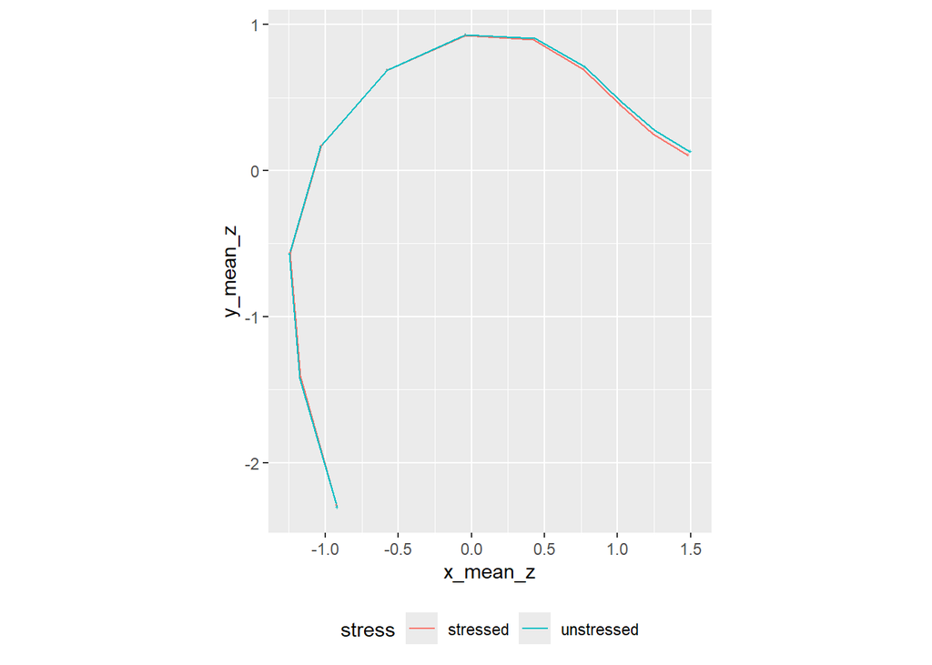

```r
stress_mvgam_plot
```

Only a small difference between the two tongue shapes is visible. The tongue shape of the rhotics articulated in stressed syllables seems to be slightly steeper and the tongue tip is further down compared to the tongue shape during the unstressed rhotics.

### 1.1.2 add participant as a factor smooth

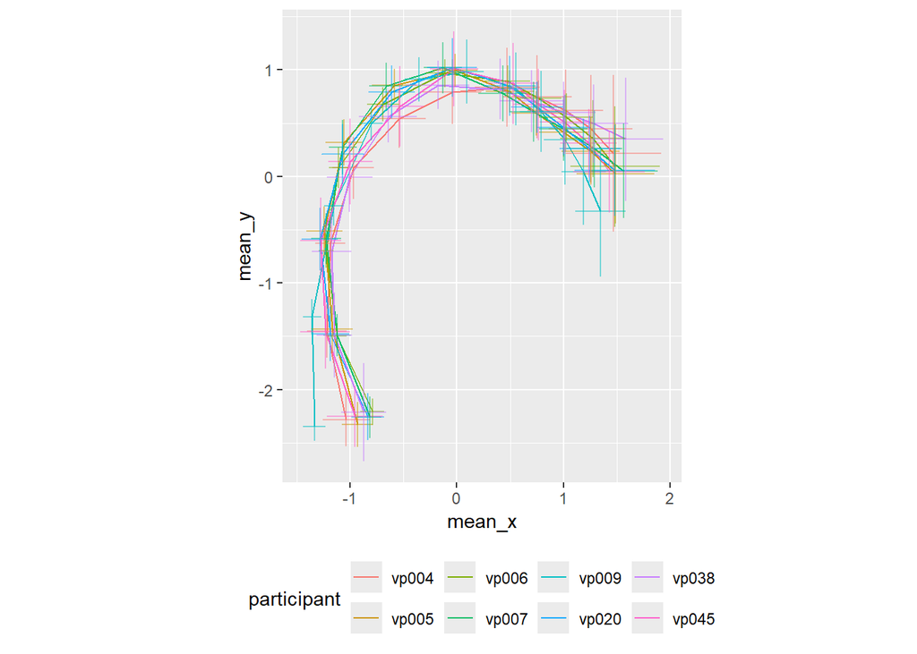

```r
uvular_static %>%
  group_by(participant, knot) %>%
  summarise(
    mean_x = mean(x_mean_z),
    mean_y = mean(y_mean_z),
    x_hi = mean(x_mean_z) + 1.96 * sd(x_mean_z),
    x_lo = mean(x_mean_z) - 1.96 * sd(x_mean_z),
    y_hi = mean(y_mean_z) + 1.96 * sd(y_mean_z),
    y_lo = mean(y_mean_z) - 1.96 * sd(y_mean_z)
  ) %>%
  ggplot(aes(mean_x, mean_y, group = participant, color = participant)) +
  geom_path() +
  geom_errorbarh(aes(xmin = x_lo, xmax = x_hi), alpha = 0.5) +
  geom_errorbar(aes(ymin = y_lo, ymax = y_hi), alpha = 0.5) +
  coord_fixed() +
  theme(legend.position = "bottom")
```

We want to take this difference into consideration and use the speaker variable as a non-linear random effect/“factor smooth” to model the non-linear difference of the tongue shape for each speaker. `stress` is added as a `by` variable to model the individual variability between the two different stress conditions.

```r
uvular_static$participant <- as.factor(uvular_static$participant)
stress_mvgam_fs <- mgcv::gam(list(
    x_mean_z ~ stress +
      s(knot, by = stress, k = 5) +
      s(knot, participant, by = stress, bs = "fs", m = 1), # using participant as a factor smooth as in Coretta (2025)
    y_mean_z ~ stress +
      s(knot, by = stress, k = 5) +
      s(knot, participant, by = stress, bs = "fs", m = 1)
  ),
  data = uvular_static,
  family = mvn(d = 2) # multivariate normal family, two dimensions
)
```

GAM summary:

```r
summary(stress_mvgam_fs)
```

```
Family: Multivariate normal
Link function:

Formula:
x_mean_z ~ stress + s(knot, by = stress, k = 5) + s(knot, participant,
    by = stress, bs = "fs", m = 1)
y_mean_z ~ stress + s(knot, by = stress, k = 5) + s(knot, participant,
    by = stress, bs = "fs", m = 1)

Parametric coefficients:
                    Estimate Std. Error z value Pr(>|z|)
(Intercept)        -0.004381   0.001833  -2.390   0.0168 *
stressunstressed    0.003808   0.002322   1.640   0.1010
(Intercept).1      -0.007183   0.003879  -1.852   0.0641 .
stressunstressed.1  0.004320   0.005016   0.861   0.3892
---
Signif. codes:  0 '***' 0.001 '**' 0.01 '*' 0.05 '.' 0.1 ' ' 1

Approximate significance of smooth terms:
                                          edf Ref.df Chi.sq p-value
s(knot):stressstressed                  3.986  3.987   1556  <2e-16 ***
s(knot):stressunstressed                3.986  3.987   1579  <2e-16 ***
s(knot,participant):stressstressed     62.713 71.000   3916  <2e-16 ***
s(knot,participant):stressunstressed   60.359 71.000   3273  <2e-16 ***
s.1(knot):stressstressed                3.977  3.978   1906  <2e-16 ***
s.1(knot):stressunstressed              3.978  3.979   2043  <2e-16 ***
s.1(knot,participant):stressstressed   64.460 72.000   5185  <2e-16 ***
s.1(knot,participant):stressunstressed 63.540 71.000   4297  <2e-16 ***
---
Signif. codes:  0 '***' 0.001 '**' 0.01 '*' 0.05 '.' 0.1 ' ' 1

Deviance explained = 98.1%
-REML = -69179  Scale est. = 1         n = 22792
```

Predict the tongue contours from the GAMM:

```r
stress_mvgam_fs_frame <- expand_grid(
  stress = uvular_static$stress %>% levels(),
  knot = seq(0, 10, by = 1),
  participant = uvular_static$participant %>% levels()
)
```

```r
stress_mvgam_fs_predict <- predict(stress_mvgam_fs, stress_mvgam_fs_frame, se.fit = T) %>%
  as.data.frame() %>%
  as_tibble()

# Rename columns
colnames(stress_mvgam_fs_predict) <- c("x_mean_z", "y_mean_z", "x_mean_se", "y_mean_se")

# combine both data frames
stress_mvgam_fs_predict <- bind_cols(stress_mvgam_fs_frame, stress_mvgam_fs_predict) %>%
  mutate(
    # calculate the lower and upper limits of 95% Confidence intervals (CI)
    x_mean_lo = x_mean_z - (1.96 * x_mean_se),
    x_mean_hi = x_mean_z + (1.96 * x_mean_se),
    y_mean_lo = y_mean_z - (1.96 * y_mean_se),
    y_mean_hi = y_mean_z + (1.96 * y_mean_se)
  )
```

Plot of the different speakers:

```r
stress_mvgam_fs_plot <- stress_mvgam_fs_predict %>%
  ggplot(aes(x_mean_z, y_mean_z, group = stress, color = stress)) +
  geom_path() +
  geom_errorbarh(aes(xmin = x_mean_lo, xmax = x_mean_hi), alpha = 0.5) +
  geom_errorbar(aes(ymin = y_mean_lo, ymax = y_mean_hi), alpha = 0.5) +
  coord_fixed() +
  facet_wrap(vars(participant), ncol = 4) +
  theme(legend.position = "bottom")
```

MV-GAM: stressed vs unstressed uvular rhotics, factor-smooth: difference over knot with respect to general pattern for each of the participants, allowing for individual variability by stress

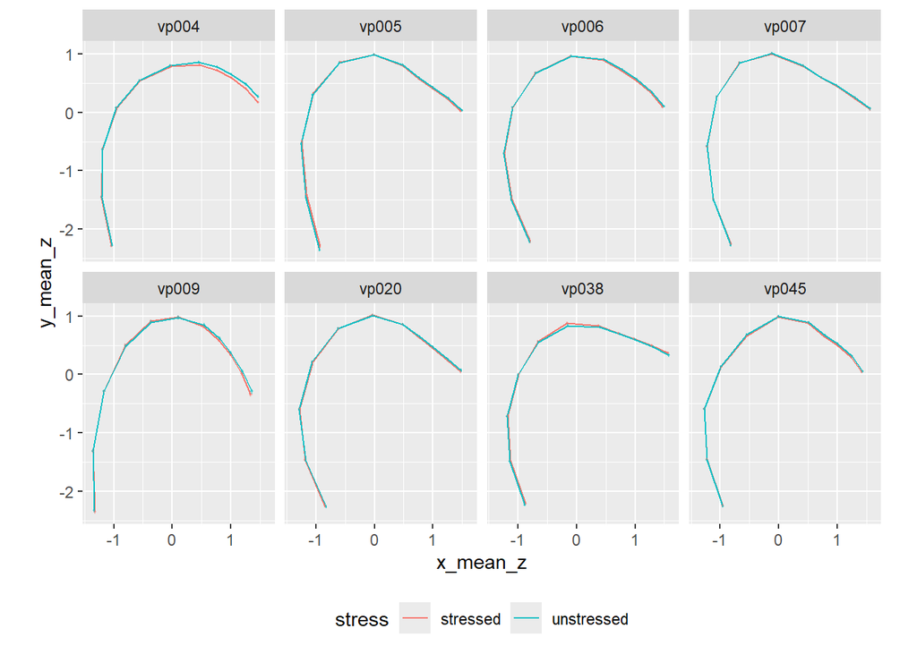

```r
stress_mvgam_fs_plot
```

Now we want to exclude the factor smooths from the prediction (see Coretta and Sakr (2025)) and get a general plot displaying the differences between uvular rhotics in stressed and unstressed syllables:

```r
excl <- c("s(knot,factor(participant)):stressstressed", "s(knot,factor(participant)):stressunstressed", "s.1(knot,factor(participant)):stressstressed", "s.1(knot,factor(participant)):stressunstressed")
```

```r
stress_mvgam_fs_predict_ex <- predict(stress_mvgam_fs, stress_mvgam_fs_frame, se.fit = T, exclude = excl) %>%
  as.data.frame() %>%
  as_tibble()

# Rename columns
colnames(stress_mvgam_fs_predict_ex) <- c("x_mean_z", "y_mean_z", "x_mean_se", "y_mean_se")

# combine both data frames
stress_mvgam_fs_predict_ex <- bind_cols(stress_mvgam_fs_frame, stress_mvgam_fs_predict_ex) %>%
  mutate(
    # calculate the lower and upper limits of 95% Confidence intervals (CI)
    x_mean_lo = x_mean_z - (1.96 * x_mean_se),
    x_mean_hi = x_mean_z + (1.96 * x_mean_se),
    y_mean_lo = y_mean_z - (1.96 * y_mean_se),
    y_mean_hi = y_mean_z + (1.96 * y_mean_se)
  )
```

Now we plot:

```r
stress_mvgam_fs_ex_plot <- stress_mvgam_fs_predict_ex %>% subset(participant == "vp004") %>%
  ggplot(aes(x_mean_z, y_mean_z, group = stress, color = stress)) +
  geom_path() +
  geom_errorbarh(aes(xmin = x_mean_lo, xmax = x_mean_hi), alpha = 0.5) +
  geom_errorbar(aes(ymin = y_mean_lo, ymax = y_mean_hi), alpha = 0.5) +
  coord_fixed() +
  theme(legend.position = "bottom")
```

MV-GAM: stressed vs unstressed uvular rhotics, excluded factor smooth over knot for participant by stress

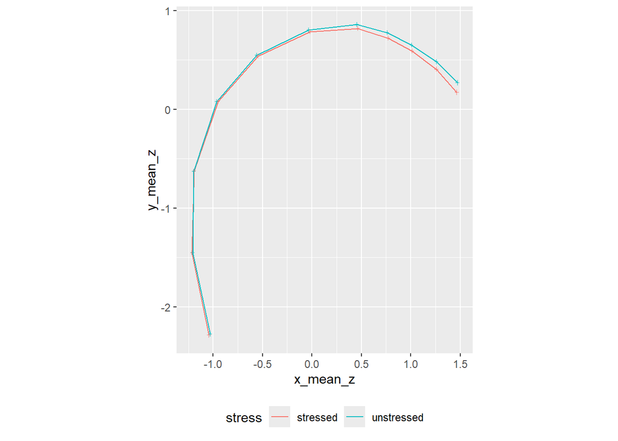

```r
stress_mvgam_fs_ex_plot
```

## 1.2 UV GAMM

Now I will do the same but this time using a univariate GAMM as proposed in Gubian (2025). Our variable encoding `stress` and `dimension` is `stress.dim`.

### 1.2.1 without random effect

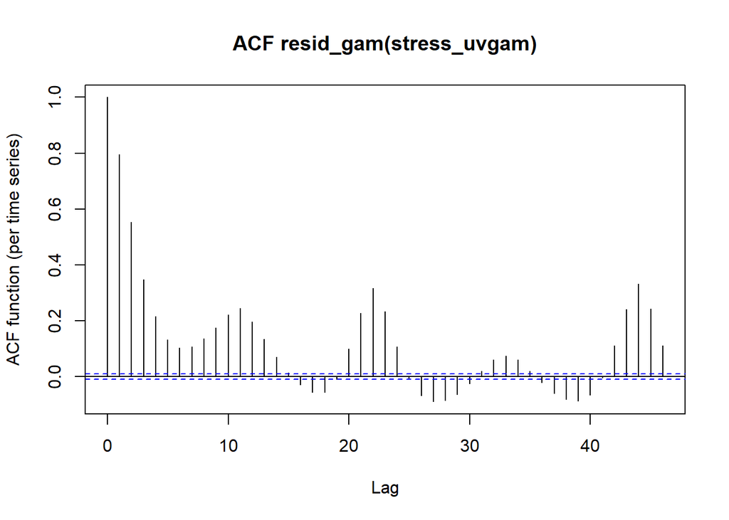

```r
uvular_static_long <- uvular_static %>%
  pivot_longer(c(x_mean_z,y_mean_z), names_to = "dimension", values_to = "position") %>%
  mutate(stress.dim = paste0(stress,".",dimension)) %>%
  mutate(stress.dim = factor(stress.dim)) %>%
  arrange(clip_id, stress.dim, knot) %>% select(-c("x_mean", "y_mean"))

stress_uvgam <- bam(position ~ stress.dim + s(knot, by = stress.dim),
                    data = uvular_static_long,
                    family = "scat",
                    discrete = T)
AR1.rho <- acf_resid(stress_uvgam)[2]
```

```r
stress_uvgam <- bam(position ~ stress.dim + s(knot, by = stress.dim),
                    data = uvular_static_long,
                    rho = AR1.rho,
                    AR.start = uvular_static_long %>% pull(knot) == 0,
                    family = "scat",
                    discrete = T)
```

GAM summary:

```r
summary(stress_uvgam)
```

```
Family: Scaled t(6.624,0.137)
Link function: identity

Formula:
position ~ stress.dim + s(knot, by = stress.dim)

Parametric coefficients:
                               Estimate Std. Error t value Pr(>|t|)
(Intercept)                   -0.001201   0.003330  -0.361    0.718
stress.dimstressed.y_mean_z   -0.011238   0.004709  -2.386    0.017 *
stress.dimunstressed.x_mean_z  0.004446   0.004832   0.920    0.358
stress.dimunstressed.y_mean_z -0.004877   0.004832  -1.009    0.313
---
Signif. codes:  0 '***' 0.001 '**' 0.01 '*' 0.05 '.' 0.1 ' ' 1

Approximate significance of smooth terms:
                                        edf Ref.df     F p-value
s(knot):stress.dimstressed.x_mean_z   8.992      9 25182  <2e-16 ***
s(knot):stress.dimstressed.y_mean_z   8.994      9 42738  <2e-16 ***
s(knot):stress.dimunstressed.x_mean_z 8.992      9 23195  <2e-16 ***
s(knot):stress.dimunstressed.y_mean_z 8.993      9 38945  <2e-16 ***
---
Signif. codes:  0 '***' 0.001 '**' 0.01 '*' 0.05 '.' 0.1 ' ' 1

R-sq.(adj) =  0.973   Deviance explained =   90%
fREML =  49533  Scale est. = 1         n = 45584
```

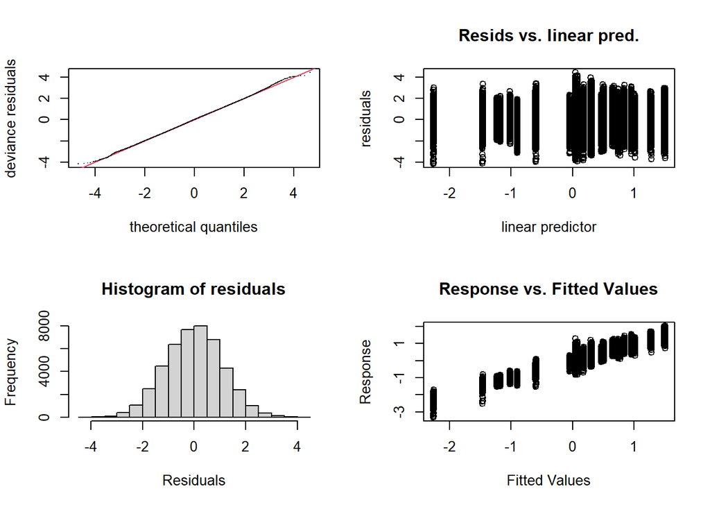

```
Method: fREML   Optimizer: perf chol
$grad
[1] -1.104450e-12  1.187482e-09 -1.102674e-12  1.692775e-10

$hess
              [,1]          [,2]         [,3]          [,4]
[1,]  3.997257e+00  6.912799e-22 2.593767e-22 -5.335928e-22
[2,] -2.006584e-21  3.998172e+00 8.124170e-38  2.615463e-37
[3,] -2.993618e-21 -2.657788e-37 3.997079e+00  7.093197e-38
[4,] -4.735710e-21  3.843674e-36 2.527116e-38  3.998082e+00

Model rank =  40 / 40

Basis dimension (k) checking results. Low p-value (k-index<1) may
indicate that k is too low, especially if edf is close to k'.

                                        k'  edf k-index p-value
s(knot):stress.dimstressed.x_mean_z   9.00 8.99    0.99    0.25
s(knot):stress.dimstressed.y_mean_z   9.00 8.99    0.99    0.23
s(knot):stress.dimunstressed.x_mean_z 9.00 8.99    0.99    0.22
s(knot):stress.dimunstressed.y_mean_z 9.00 8.99    0.99    0.18
```

```r
gam.check(stress_uvgam)
```

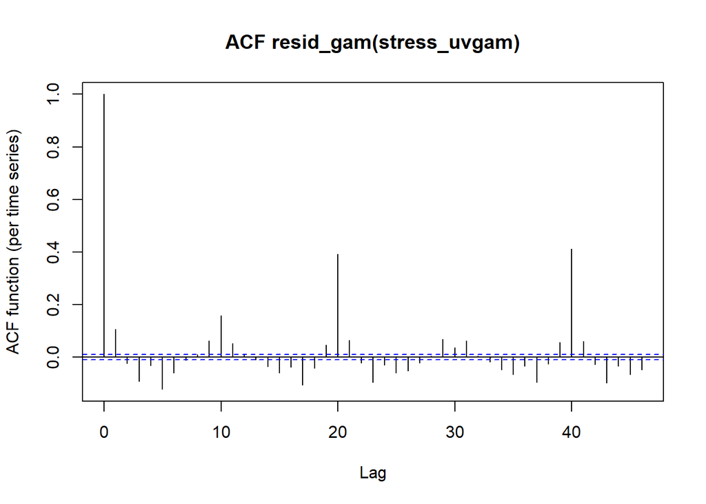

```r
acf_resid(stress_uvgam)
```

Predict the tongue contours from the GAMM:

```r
stress_uvgam_frame <- expand_grid(
  knot = 0:10,
  stress.dim = uvular_static_long$stress.dim %>% levels()
)
```

```r
stress_uvgam_predict <- predict(stress_uvgam, stress_uvgam_frame, se.fit = T) %>%
  as.data.frame() %>% as_tibble() %>%
  bind_cols(stress_uvgam_frame) %>% separate_wider_delim(stress.dim, ".", names = c("stress", "dimension")) %>%
  pivot_wider(names_from = dimension, values_from = c("fit", "se.fit"))

colnames(stress_uvgam_predict) <- c("knot", "stress", "x_mean_z", "y_mean_z", "x_mean_z_se", "y_mean_z_se")
```

```r
gam_uv_pred_plot <- stress_uvgam_predict %>% ggplot() +
  aes(x_mean_z, y_mean_z, group = stress, color = stress, fill = stress) +
  geom_path() + geom_errorbarh(aes(xmin = x_mean_z - 1.96 * x_mean_z_se, xmax = x_mean_z + 1.96 * x_mean_z_se), alpha = 0.5) +
  geom_errorbar(aes(ymin = y_mean_z - 1.96 * y_mean_z_se, ymax = y_mean_z + 1.96 * y_mean_z_se), alpha = 0.5) +
  coord_fixed() +
  theme(legend.position = "bottom")
```

UV-GAM: stressed vs unstressed uvular rhotics

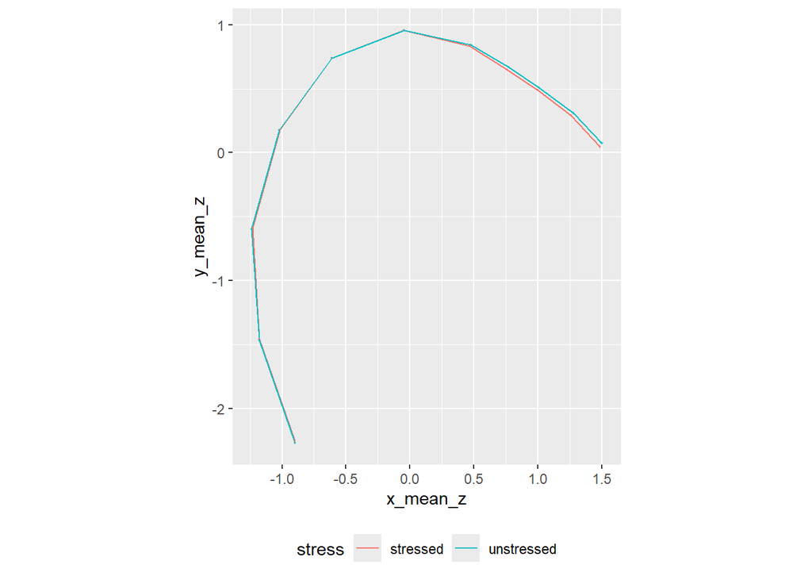

```r
gam_uv_pred_plot
```

When we compare to the multivariate GAMM:

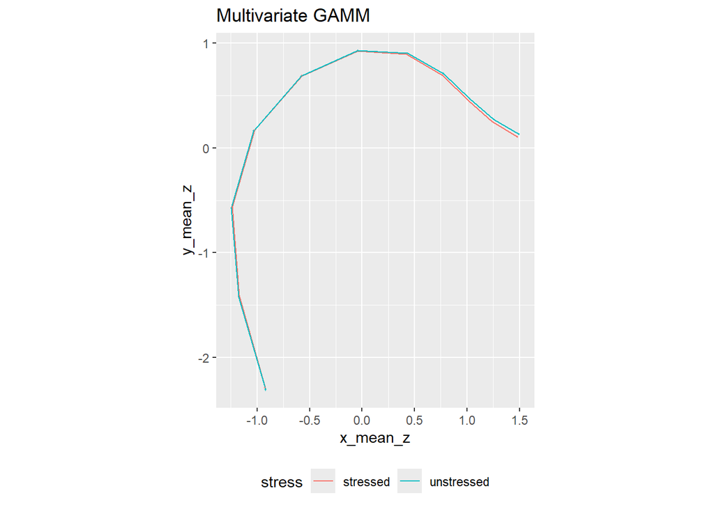

```r
par(mfrow = c(1, 2))
stress_mvgam_plot + labs(title = "Multivariate GAMM")
```

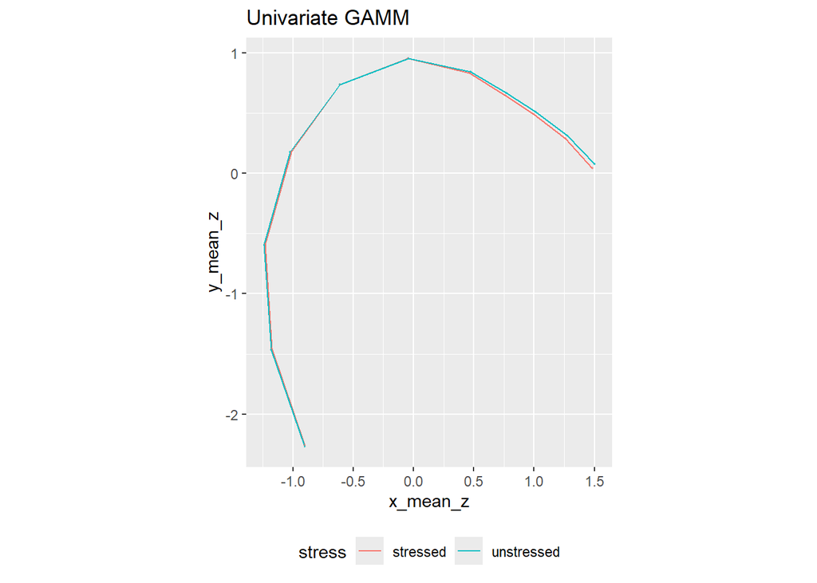

```r
gam_uv_pred_plot + labs(title = "Univariate GAMM")
```

The two plots differ in the front part of the tongue contours. But both display only a very small difference between stressed and unstressed rhotics: The tongue tip is a bit lower in the stressed rhotics.

### 1.2.2 add participant as a factor smooth

Now I want to add a factor smooth for the variable `participant` again, as I did in the MV GAMM. My question now was if I should include a `by` variable in the fs term?

#### 1.2.2.1 without by variable

Here I fit the GAM model with the factor smooth term for `participant` but without adding a `by` variable (**s(knot, participant, bs = “fs”, m = 1)**).

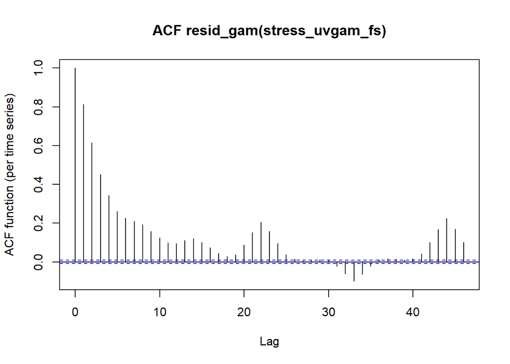

```r
uvular_static_long$participant <- as.factor(uvular_static_long$participant)
stress_uvgam_fs <- bam(position ~ stress.dim +
                         s(knot, by = stress.dim) +
                         s(knot, participant, bs = "fs", m = 1), # factor smooth for participant
                    data = uvular_static_long,
                    family = "scat",
                    discrete = T)
AR1.rho <- acf_resid(stress_uvgam_fs)[2]
```

```r
stress_uvgam_fs <- bam(position ~ stress.dim + s(knot, by = stress.dim) +
                         s(knot, participant, bs = "fs", m = 1),
                    data = uvular_static_long,
                    rho = AR1.rho,
                    AR.start = uvular_static_long %>% pull(knot) == 0,
                    family = "scat",
                    discrete = T)
```

```r
summary(stress_uvgam_fs)
```

```
Family: Scaled t(6.767,0.127)
Link function: identity

Formula:
position ~ stress.dim + s(knot, by = stress.dim) + s(knot, participant,
    bs = "fs", m = 1)

Parametric coefficients:
                               Estimate Std. Error t value Pr(>|t|)
(Intercept)                   -0.004829   0.003603  -1.340   0.1802
stress.dimstressed.y_mean_z   -0.007397   0.004461  -1.658   0.0973 .
stress.dimunstressed.x_mean_z  0.005416   0.004578   1.183   0.2368
stress.dimunstressed.y_mean_z -0.001573   0.004578  -0.344   0.7312
---
Signif. codes:  0 '***' 0.001 '**' 0.01 '*' 0.05 '.' 0.1 ' ' 1

Approximate significance of smooth terms:
                                         edf Ref.df     F p-value
s(knot):stress.dimstressed.x_mean_z    8.745  8.762 156.8  <2e-16 ***
s(knot):stress.dimstressed.y_mean_z    8.824  8.836 269.8  <2e-16 ***
s(knot):stress.dimunstressed.x_mean_z  8.744  8.761 159.3  <2e-16 ***
s(knot):stress.dimunstressed.y_mean_z  8.821  8.833 269.0  <2e-16 ***
s(knot,participant)                   61.177 71.000 221.9  <2e-16 ***
---
Signif. codes:  0 '***' 0.001 '**' 0.01 '*' 0.05 '.' 0.1 ' ' 1

R-sq.(adj) =  0.977   Deviance explained = 90.7%
fREML =  47911  Scale est. = 1         n = 45584
```

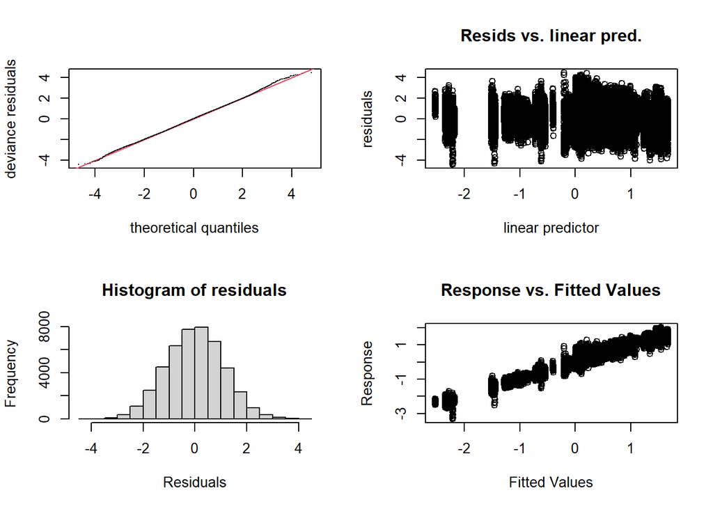

```
Method: fREML   Optimizer: perf chol
$grad
[1] -2.951683e-11 -2.270228e-11 -2.890710e-11 -2.190825e-11 -2.549214e-10
[6]  4.678924e-12

$hess
              [,1]          [,2]          [,3]          [,4]         [,5]
[1,]  3.847875e+00 -0.0676179274 -1.471690e-01 -0.0673906107 -0.436960584
[2,] -6.761793e-02  3.8477998925 -6.556231e-02 -0.1479678269 -0.323945353
[3,] -1.471690e-01 -0.0655623145  3.851765e+00 -0.0653145642 -0.433360159
[4,] -6.739061e-02 -0.1479678269 -6.531456e-02  3.8502350920 -0.335480806
[5,] -4.369606e-01 -0.3239453526 -4.333602e-01 -0.3354808058 21.922980446
[6,] -6.214486e-05 -0.0001334907 -3.511913e-05 -0.0001447648 -0.005319359
              [,6]
[1,] -6.214486e-05
[2,] -1.334907e-04
[3,] -3.511913e-05
[4,] -1.447648e-04
[5,] -5.319359e-03
[6,]  1.015412e+00

Model rank =  112 / 112

Basis dimension (k) checking results. Low p-value (k-index<1) may
indicate that k is too low, especially if edf is close to k'.

                                         k'   edf k-index p-value
s(knot):stress.dimstressed.x_mean_z    9.00  8.74    0.99    0.14
s(knot):stress.dimstressed.y_mean_z    9.00  8.82    0.99    0.23
s(knot):stress.dimunstressed.x_mean_z  9.00  8.74    0.99    0.17
s(knot):stress.dimunstressed.y_mean_z  9.00  8.82    0.99    0.18
s(knot,participant)                   72.00 61.18    0.99    0.20
```

```r
gam.check(stress_uvgam_fs)
```

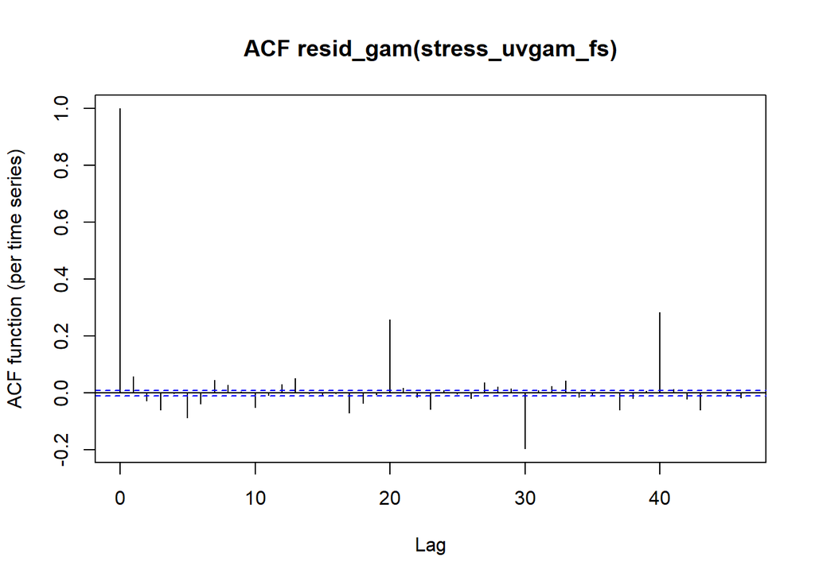

```r
acf_resid(stress_uvgam_fs)
```

Predict the tongue contours from the GAMM:

```r
stress_uvgam_fs_frame <- expand_grid(
  knot = 0:10,
  stress.dim = uvular_static_long$stress.dim %>% levels(),
  participant = uvular_static_long$participant %>% levels()
)
```

```r
stress_uvgam_fs_predict <- predict(stress_uvgam_fs, stress_uvgam_fs_frame, se.fit = T) %>%
  as.data.frame() %>% as_tibble() %>%
  bind_cols(stress_uvgam_fs_frame) %>% separate_wider_delim(stress.dim, ".", names = c("stress", "dimension")) %>%
  pivot_wider(names_from = dimension, values_from = c("fit", "se.fit"))

colnames(stress_uvgam_fs_predict) <- c("knot", "stress", "participant", "x_mean_z", "y_mean_z", "x_mean_z_se", "y_mean_z_se")
```

```r
gam_uv_fs_pred_plot <- stress_uvgam_fs_predict %>% ggplot() +
  aes(x_mean_z, y_mean_z, group = stress, color = stress, fill = stress) +
  geom_path() + geom_errorbarh(aes(xmin = x_mean_z - 1.96 * x_mean_z_se, xmax = x_mean_z + 1.96 * x_mean_z_se), alpha = 0.5) +
  geom_errorbar(aes(ymin = y_mean_z - 1.96 * y_mean_z_se, ymax = y_mean_z + 1.96 * y_mean_z_se), alpha = 0.5) +
  facet_wrap(vars(participant), ncol = 4) +
  coord_fixed() +
  theme(legend.position = "bottom")
```

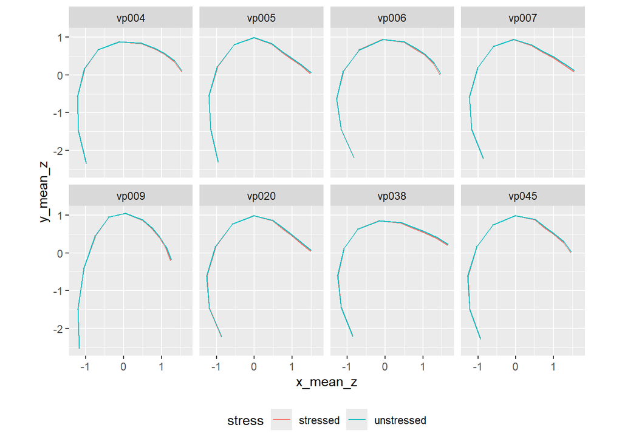

```r
gam_uv_fs_pred_plot
```

Looks very similar to the multivariate predicted contours of the participants.

Now I want to remove the factor smooth for participant:

```r
excl <- c("s(knot,participant)")
```

```r
stress_uvgam_fs_predict2 <- predict(stress_uvgam_fs, stress_uvgam_fs_frame, se.fit = T, exclude = excl) %>%
  as.data.frame() %>% as_tibble() %>%
  bind_cols(stress_uvgam_fs_frame) %>% separate_wider_delim(stress.dim, ".", names = c("stress", "dimension")) %>%
  pivot_wider(names_from = dimension, values_from = c("fit", "se.fit"))

colnames(stress_uvgam_fs_predict2) <- c("knot", "stress", "participant", "x_mean_z", "y_mean_z", "x_mean_z_se", "y_mean_z_se")
```

```r
gam_uv_fs_pred_plot2 <- stress_uvgam_fs_predict2 %>% subset(participant == "vp004") %>% ggplot() +
  aes(x_mean_z, y_mean_z, group = stress, color = stress, fill = stress) +
  geom_path() + geom_errorbarh(aes(xmin = x_mean_z - 1.96 * x_mean_z_se, xmax = x_mean_z + 1.96 * x_mean_z_se), alpha = 0.5) +
  geom_errorbar(aes(ymin = y_mean_z - 1.96 * y_mean_z_se, ymax = y_mean_z + 1.96 * y_mean_z_se), alpha = 0.5) +
  coord_fixed() +
  theme(legend.position = "bottom")
```

UV-GAM: stressed vs unstressed uvular rhotics, excluded factor smooth over knot for participant

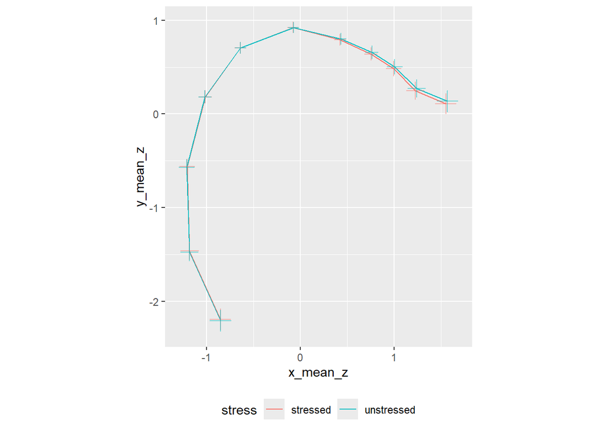

```r
gam_uv_fs_pred_plot2
```

This looks alright.

Now we could calculate a difference curve for this, e.g.:

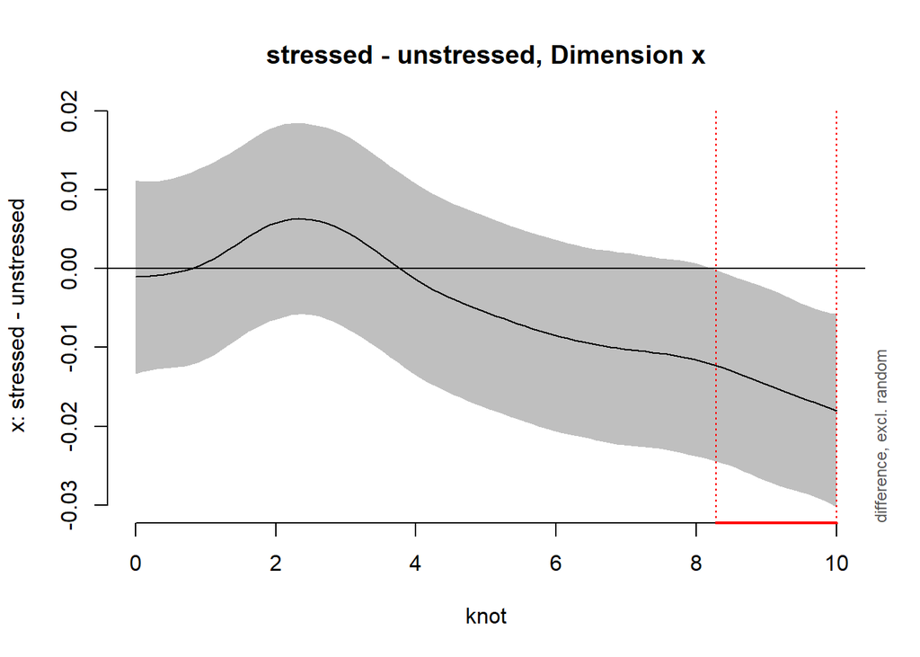

```r
plot_diff(stress_uvgam_fs, view = "knot", comp = list(stress.dim = c("stressed.x_mean_z", "unstressed.x_mean_z")),
            print.summary = FALSE, main = "stressed - unstressed, Dimension x", ylab = "x: stressed - unstressed")
```

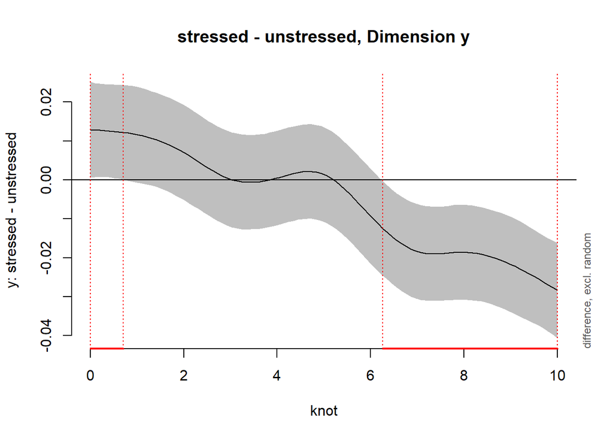

```r
plot_diff(stress_uvgam_fs, view = "knot", comp = list(stress.dim = c("stressed.y_mean_z", "unstressed.y_mean_z")),
            print.summary = FALSE, main = "stressed - unstressed, Dimension y", ylab = "y: stressed - unstressed")
```

#### 1.2.2.2 with stress.dim as by variable

Now I will include stress.dim as a `by` variable. It makes sense to me because there is probably individual variability for the participants for each level of `stress.dim`.

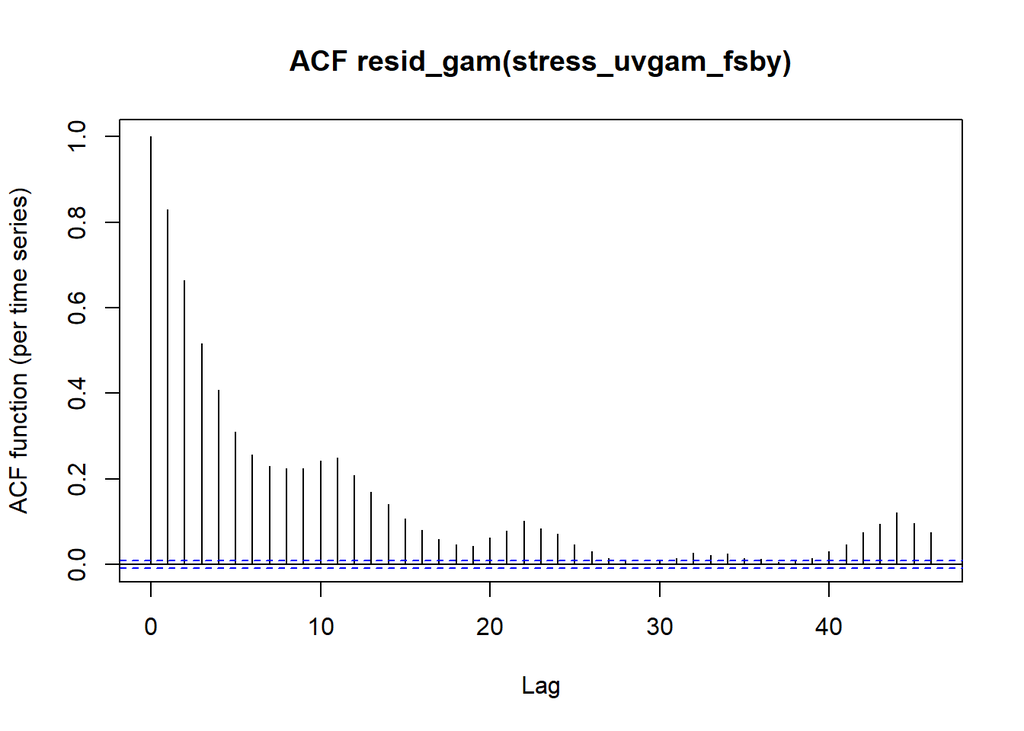

```r
stress_uvgam_fsby <- bam(position ~ stress.dim +
                         s(knot, by = stress.dim) +
                         s(knot, participant, by = stress.dim, bs = "fs", m = 1), # factor smooth for participant
                    data = uvular_static_long,
                    family = "scat",
                    discrete = T)
AR1.rho <- acf_resid(stress_uvgam_fsby)[2]
```

```r
stress_uvgam_fsby <- bam(position ~ stress.dim + s(knot, by = stress.dim) +
                         s(knot, participant, by = stress.dim, bs = "fs", m = 1),
                    data = uvular_static_long,
                    rho = AR1.rho,
                    AR.start = uvular_static_long %>% pull(knot) == 0,
                    family = "scat",
                    discrete = T)
```

```r
summary(stress_uvgam_fsby)
```

```
Family: Scaled t(5.442,0.114)
Link function: identity

Formula:
position ~ stress.dim + s(knot, by = stress.dim) + s(knot, participant,
    by = stress.dim, bs = "fs", m = 1)

Parametric coefficients:
                               Estimate Std. Error t value Pr(>|t|)
(Intercept)                   -0.004800   0.003913  -1.227    0.220
stress.dimstressed.y_mean_z   -0.010474   0.007299  -1.435    0.151
stress.dimunstressed.x_mean_z  0.005245   0.004996   1.050    0.294
stress.dimunstressed.y_mean_z -0.002118   0.004997  -0.424    0.672

Approximate significance of smooth terms:
                                                     edf Ref.df      F p-value
s(knot):stress.dimstressed.x_mean_z                8.644  8.653  129.1  <2e-16
s(knot):stress.dimstressed.y_mean_z                8.578  8.605  197.0  <2e-16
s(knot):stress.dimunstressed.x_mean_z              8.640  8.650  119.7  <2e-16
s(knot):stress.dimunstressed.y_mean_z              8.600  8.630  237.6  <2e-16
s(knot,participant):stress.dimstressed.x_mean_z   60.194 71.000 3694.2  <2e-16
s(knot,participant):stress.dimstressed.y_mean_z   62.380 71.000 6871.6  <2e-16
s(knot,participant):stress.dimunstressed.x_mean_z 57.238 71.000 1724.0  <2e-16
s(knot,participant):stress.dimunstressed.y_mean_z 56.810 71.000 2618.5  <2e-16

s(knot):stress.dimstressed.x_mean_z               ***
s(knot):stress.dimstressed.y_mean_z               ***
s(knot):stress.dimunstressed.x_mean_z             ***
s(knot):stress.dimunstressed.y_mean_z             ***
s(knot,participant):stress.dimstressed.x_mean_z   ***
s(knot,participant):stress.dimstressed.y_mean_z   ***
s(knot,participant):stress.dimunstressed.x_mean_z ***
s(knot,participant):stress.dimunstressed.y_mean_z ***
---
Signif. codes:  0 '***' 0.001 '**' 0.01 '*' 0.05 '.' 0.1 ' ' 1

R-sq.(adj) =   0.98   Deviance explained =   90%
fREML =  48234  Scale est. = 1         n = 45584
```

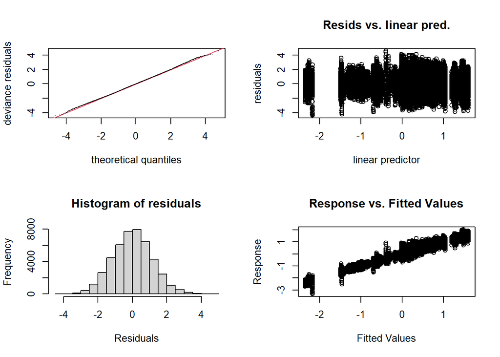

[output not shown]

[output cut: 17 more lines]

```
s(knot,participant):stress.dimstressed.x_mean_z   72.00 60.19    0.97   0.040
s(knot,participant):stress.dimstressed.y_mean_z   72.00 62.38    0.97   0.010
s(knot,participant):stress.dimunstressed.x_mean_z 72.00 57.24    0.97   0.010
s(knot,participant):stress.dimunstressed.y_mean_z 72.00 56.81    0.97   0.020

s(knot):stress.dimstressed.x_mean_z               *
s(knot):stress.dimstressed.y_mean_z               *
s(knot):stress.dimunstressed.x_mean_z             *
s(knot):stress.dimunstressed.y_mean_z             **
s(knot,participant):stress.dimstressed.x_mean_z   *
s(knot,participant):stress.dimstressed.y_mean_z   **
s(knot,participant):stress.dimunstressed.x_mean_z **
s(knot,participant):stress.dimunstressed.y_mean_z *
---
Signif. codes:  0 '***' 0.001 '**' 0.01 '*' 0.05 '.' 0.1 ' ' 1
```

```r
gam.check(stress_uvgam_fsby)
```

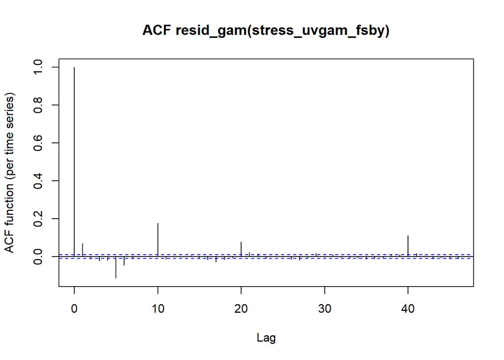

```r
acf_resid(stress_uvgam_fsby)
```

Predict the tongue contours from the GAMM:

```r
stress_uvgam_fsby_predict <- predict(stress_uvgam_fsby, stress_uvgam_fs_frame, se.fit = T) %>%
  as.data.frame() %>% as_tibble() %>%
  bind_cols(stress_uvgam_fs_frame) %>% separate_wider_delim(stress.dim, ".", names = c("stress", "dimension")) %>%
  pivot_wider(names_from = dimension, values_from = c("fit", "se.fit"))

colnames(stress_uvgam_fsby_predict) <- c("knot", "stress", "participant", "x_mean_z", "y_mean_z", "x_mean_z_se", "y_mean_z_se")
```

```r
gam_uv_fsby_pred_plot <- stress_uvgam_fsby_predict %>% ggplot() +
  aes(x_mean_z, y_mean_z, group = stress, color = stress, fill = stress) +
  geom_path() + geom_errorbarh(aes(xmin = x_mean_z - 1.96 * x_mean_z_se, xmax = x_mean_z + 1.96 * x_mean_z_se), alpha = 0.5) +
  geom_errorbar(aes(ymin = y_mean_z - 1.96 * y_mean_z_se, ymax = y_mean_z + 1.96 * y_mean_z_se), alpha = 0.5) +
  facet_wrap(vars(participant), ncol = 4) +
  coord_fixed() +
  theme(legend.position = "bottom")
```

UV-GAM: stressed vs unstressed uvular rhotics, factor smooth over knot for participant by stress.dim

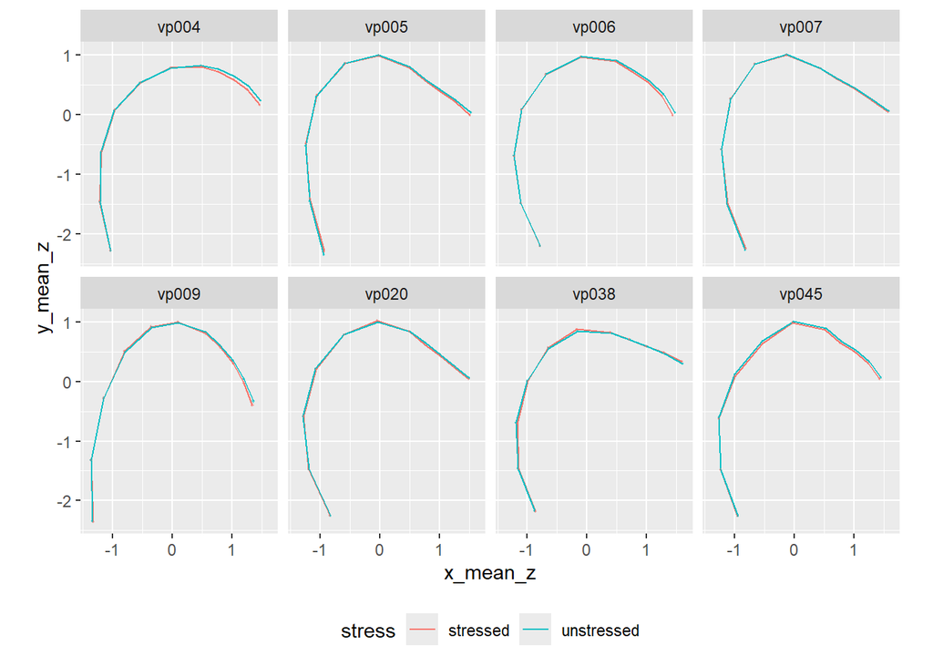

```r
gam_uv_fsby_pred_plot
```

Looks very similar to the multivariate predicted contours of the participants.

Now I want to remove the factor smooth for participant:

```r
excl <- c("s(knot,participant):stress.dimstressed.x_mean_z", "s(knot,participant):stress.dimstressed.y_mean_z", "s(knot,participant):stress.dimunstressed.x_mean_z", "s(knot,participant):stress.dimunstressed.y_mean_z")
```

```r
stress_uvgam_fsby_predict2 <- predict(stress_uvgam_fsby, stress_uvgam_fs_frame, se.fit = T, exclude = excl) %>%
  as.data.frame() %>% as_tibble() %>%
  bind_cols(stress_uvgam_fs_frame) %>% separate_wider_delim(stress.dim, ".", names = c("stress", "dimension")) %>%
  pivot_wider(names_from = dimension, values_from = c("fit", "se.fit"))

colnames(stress_uvgam_fsby_predict2) <- c("knot", "stress", "participant", "x_mean_z", "y_mean_z", "x_mean_z_se", "y_mean_z_se")
```

```r
gam_uv_fsby_pred_plot2 <- stress_uvgam_fsby_predict2 %>% subset(participant == "vp004") %>% ggplot() +
  aes(x_mean_z, y_mean_z, group = stress, color = stress, fill = stress) +
  geom_path() + geom_errorbarh(aes(xmin = x_mean_z - 1.96 * x_mean_z_se, xmax = x_mean_z + 1.96 * x_mean_z_se), alpha = 0.5) +
  geom_errorbar(aes(ymin = y_mean_z - 1.96 * y_mean_z_se, ymax = y_mean_z + 1.96 * y_mean_z_se), alpha = 0.5) +
  coord_fixed() +
  theme(legend.position = "bottom")
```

UV-GAM: stressed vs unstressed uvular rhotics, excluded factor smooth over knot for participant by stress.dim

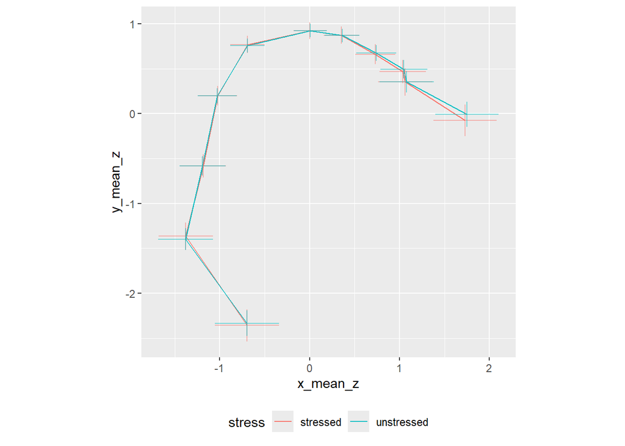

```r
gam_uv_fsby_pred_plot2
```

**Question: Why does it look weird now? Was it wrong to include stress.dim as a `by` variable in the model?**

#### 1.2.2.3 with dimension as by variable

I also tried using only dimension as the `by` variable to see if this works better:

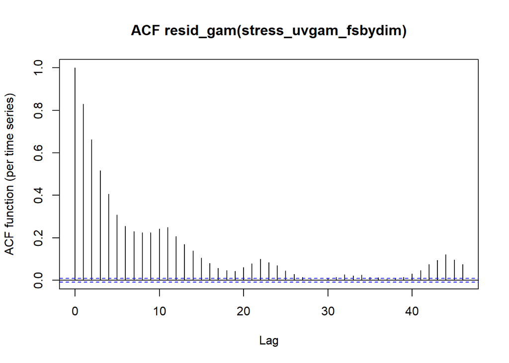

```r
uvular_static_long$dimension <- as.factor(uvular_static_long$dimension)
stress_uvgam_fsbydim <- bam(position ~ stress.dim +
                         s(knot, by = stress.dim) +
                         s(knot, participant, by = dimension, bs = "fs", m = 1), # factor smooth for participant
                    data = uvular_static_long,
                    family = "scat",
                    discrete = T)
AR1.rho <- acf_resid(stress_uvgam_fsbydim)[2]
```

```r
stress_uvgam_fsbydim <- bam(position ~ stress.dim +
                         s(knot, by = stress.dim) +
                         s(knot, participant, by = dimension, bs = "fs", m = 1), # factor smooth for participant
                    data = uvular_static_long,
                    rho = AR1.rho,
                    AR.start = uvular_static_long %>% pull(knot) == 0,
                    family = "scat",
                    discrete = T)
```

```r
summary(stress_uvgam_fsbydim)
```

```
Family: Scaled t(5.431,0.114)
Link function: identity

Formula:
position ~ stress.dim + s(knot, by = stress.dim) + s(knot, participant,
    by = dimension, bs = "fs", m = 1)

Parametric coefficients:
                               Estimate Std. Error t value Pr(>|t|)
(Intercept)                   -0.003448   0.003290  -1.048    0.295
stress.dimstressed.y_mean_z   -0.008233   0.005253  -1.567    0.117
stress.dimunstressed.x_mean_z  0.005510   0.004300   1.281    0.200
stress.dimunstressed.y_mean_z -0.001233   0.005346  -0.231    0.818

Approximate significance of smooth terms:
                                         edf Ref.df      F p-value
s(knot):stress.dimstressed.x_mean_z    8.659  8.664  240.6  <2e-16 ***
s(knot):stress.dimstressed.y_mean_z    8.616  8.633  240.6  <2e-16 ***
s(knot):stress.dimunstressed.x_mean_z  8.657  8.662  242.1  <2e-16 ***
s(knot):stress.dimunstressed.y_mean_z  8.614  8.631  238.4  <2e-16 ***
s(knot,participant):dimensionx_mean_z 59.718 71.000 1312.4  <2e-16 ***
s(knot,participant):dimensiony_mean_z 61.905 71.000  477.4  <2e-16 ***
---
Signif. codes:  0 '***' 0.001 '**' 0.01 '*' 0.05 '.' 0.1 ' ' 1

R-sq.(adj) =   0.98   Deviance explained =   90%
fREML =  47765  Scale est. = 1         n = 45584
```

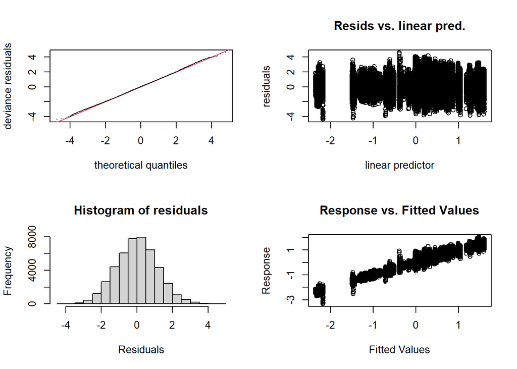

```
Method: fREML   Optimizer: perf chol
$grad
[1]  3.744605e-09  8.908834e-07  6.923258e-10  1.262887e-07  5.450111e-10
[6] -5.618668e-07 -5.745060e-08  1.217293e-10

$hess
              [,1]          [,2]          [,3]          [,4]          [,5]
[1,]  3.768943e+00  8.130352e-19 -2.304323e-01  3.254030e-19 -2.976806e-02
[2,]  1.296426e-18  3.753187e+00  6.103105e-19 -2.480005e-01  3.623885e-18
[3,] -2.304323e-01  3.501614e-19  3.768833e+00  1.401459e-19 -3.103548e-02
[4,]  1.325083e-18 -2.480005e-01  6.243606e-19  3.746260e+00  3.676852e-18
[5,] -2.976806e-02  2.475769e-18 -3.103548e-02  9.908828e-19  2.636306e+01
[6,] -4.573817e-05 -2.568897e-17 -4.221181e-05 -1.028156e-17 -6.894473e-04
[7,] -8.841677e-18 -4.572326e-01 -4.517890e-18 -4.581355e-01 -2.410113e-17
[8,] -4.655842e-19 -3.268360e-05 -2.109076e-19 -3.955867e-05 -1.633327e-18
              [,6]          [,7]          [,8]
[1,] -4.573817e-05 -7.253196e-18 -6.341122e-19
[2,] -3.745428e-17 -4.572326e-01 -3.268360e-05
[3,] -4.221181e-05 -3.123837e-18 -2.731021e-19
[4,] -3.775122e-17 -4.581355e-01 -3.955867e-05
[5,] -6.894473e-04 -2.208667e-17 -1.930931e-18
[6,]  3.447935e-01  2.291748e-16  2.003565e-17
[7,]  2.706862e-16  2.317140e+01  8.340191e-03
[8,]  1.627766e-17  8.340191e-03  1.393987e+00

Model rank =  184 / 184

Basis dimension (k) checking results. Low p-value (k-index<1) may
indicate that k is too low, especially if edf is close to k'.

                                         k'   edf k-index p-value
s(knot):stress.dimstressed.x_mean_z    9.00  8.66    0.98   0.105
s(knot):stress.dimstressed.y_mean_z    9.00  8.62    0.98   0.105
s(knot):stress.dimunstressed.x_mean_z  9.00  8.66    0.98   0.095 .
s(knot):stress.dimunstressed.y_mean_z  9.00  8.61    0.98   0.075 .
s(knot,participant):dimensionx_mean_z 72.00 59.72    0.98   0.075 .
s(knot,participant):dimensiony_mean_z 72.00 61.90    0.98   0.080 .
---
Signif. codes:  0 '***' 0.001 '**' 0.01 '*' 0.05 '.' 0.1 ' ' 1
```

```r
gam.check(stress_uvgam_fsbydim)
```

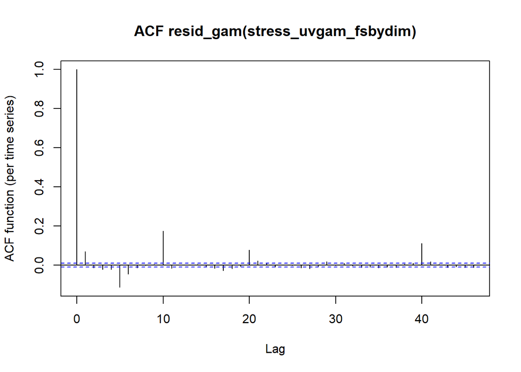

```r
acf_resid(stress_uvgam_fsbydim)
```

Prediction:

```r
stress_uvgam_fsbydim_frame <- expand_grid(
  knot = 0:10,
  stress.dim = uvular_static_long$stress.dim %>% levels(),
  participant = uvular_static_long$participant %>% levels()
) %>% mutate(
  dimension = case_when(
    str_detect(stress.dim, "x_mean_z") ~ "x_mean_z",
    str_detect(stress.dim, "y_mean_z") ~ "y_mean_z"
  )
)
```

```r
stress_uvgam_fsbydim_predict <- predict(stress_uvgam_fsbydim, stress_uvgam_fsbydim_frame, se.fit = T) %>%
  as.data.frame() %>% as_tibble() %>%
  bind_cols(stress_uvgam_fsbydim_frame) %>% select(-c("dimension")) %>%  separate_wider_delim(stress.dim, ".", names = c("stress", "dimension")) %>%
  pivot_wider(names_from = dimension, values_from = c("fit", "se.fit"))

colnames(stress_uvgam_fsbydim_predict) <- c("knot", "stress", "participant", "x_mean_z", "y_mean_z", "x_mean_z_se", "y_mean_z_se")
```

```r
stress_uvgam_fsbydim_pred_plot <- stress_uvgam_fsbydim_predict %>% ggplot() +
  aes(x_mean_z, y_mean_z, group = stress, color = stress, fill = stress) +
  geom_path() + geom_errorbarh(aes(xmin = x_mean_z - 1.96 * x_mean_z_se, xmax = x_mean_z + 1.96 * x_mean_z_se), alpha = 0.5) +
  geom_errorbar(aes(ymin = y_mean_z - 1.96 * y_mean_z_se, ymax = y_mean_z + 1.96 * y_mean_z_se), alpha = 0.5) +
  facet_wrap(vars(participant), ncol = 4) +
  coord_fixed() +
  theme(legend.position = "bottom")
```

UV-GAM: stressed vs unstressed uvular rhotics, factor smooth over knot for participant by dimension

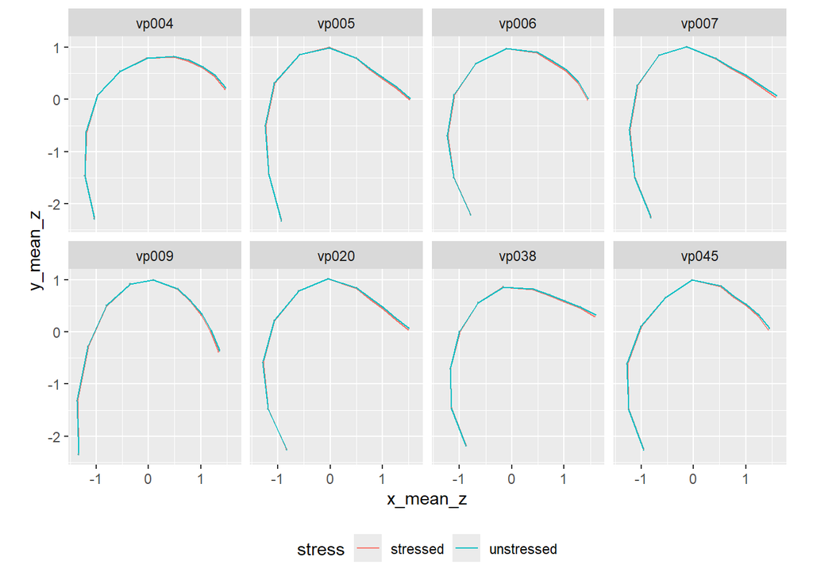

```r
stress_uvgam_fsbydim_pred_plot
```

Then we remove the factor smooth for participant:

```r
excl <- c("s(knot,participant):dimensionx_mean_z", "s(knot,participant):dimensiony_mean_z")
```

```r
stress_uvgam_fsbydim_predict2 <- predict(stress_uvgam_fsbydim, stress_uvgam_fsbydim_frame, se.fit = T, exclude = excl) %>%
  as.data.frame() %>% as_tibble() %>%
  bind_cols(stress_uvgam_fsbydim_frame) %>% select(-c("dimension")) %>%  separate_wider_delim(stress.dim, ".", names = c("stress", "dimension")) %>%
  pivot_wider(names_from = dimension, values_from = c("fit", "se.fit"))

colnames(stress_uvgam_fsbydim_predict2) <- c("knot", "stress", "participant", "x_mean_z", "y_mean_z", "x_mean_z_se", "y_mean_z_se")
```

```r
stress_uvgam_fsbydim_pred_plot2 <- stress_uvgam_fsbydim_predict2 %>% subset(participant == "vp005") %>% ggplot() +
  aes(x_mean_z, y_mean_z, group = stress, color = stress, fill = stress) +
  geom_path() + geom_errorbarh(aes(xmin = x_mean_z - 1.96 * x_mean_z_se, xmax = x_mean_z + 1.96 * x_mean_z_se), alpha = 0.5) +
  geom_errorbar(aes(ymin = y_mean_z - 1.96 * y_mean_z_se, ymax = y_mean_z + 1.96 * y_mean_z_se), alpha = 0.5) +
  coord_fixed() +
  theme(legend.position = "bottom")
```

UV-GAM: stressed vs unstressed uvular rhotics, excluded factor smooth over knot for participant by dimension

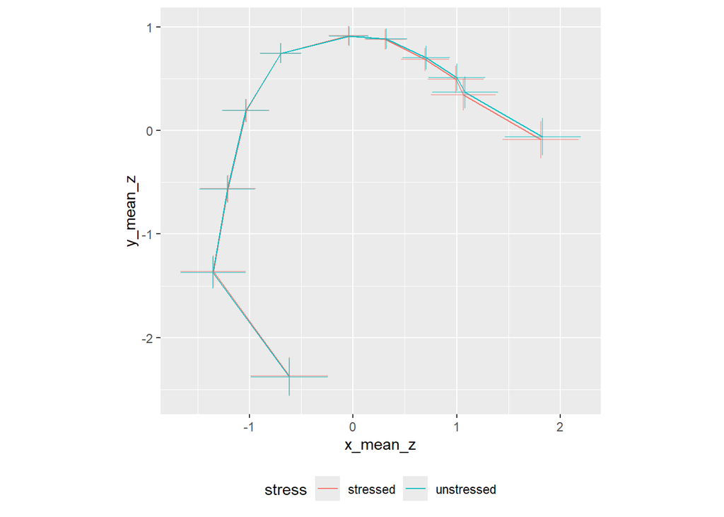

```r
stress_uvgam_fsbydim_pred_plot2
```

This looks still weird. **Question: What would be an appropriate factor smooth term for this model?**

## 1.3 adding more variables?

The GAMMs now only differentiate between tongue contours in stressed vs unstressed syllables. If I now wanted to look at differences between rhotics in stressed vs unstressed syllables but also split up in different phonetic environments (wordinitial (e.g. *Reis*) / syllableinitial (e.g. *einreisen*) / in a consonant cluster (e.g. *Kreis*)), how would this look like? Can I just add any number of variables to the equation?

Minimal example (without factor smooths) of what I mean:

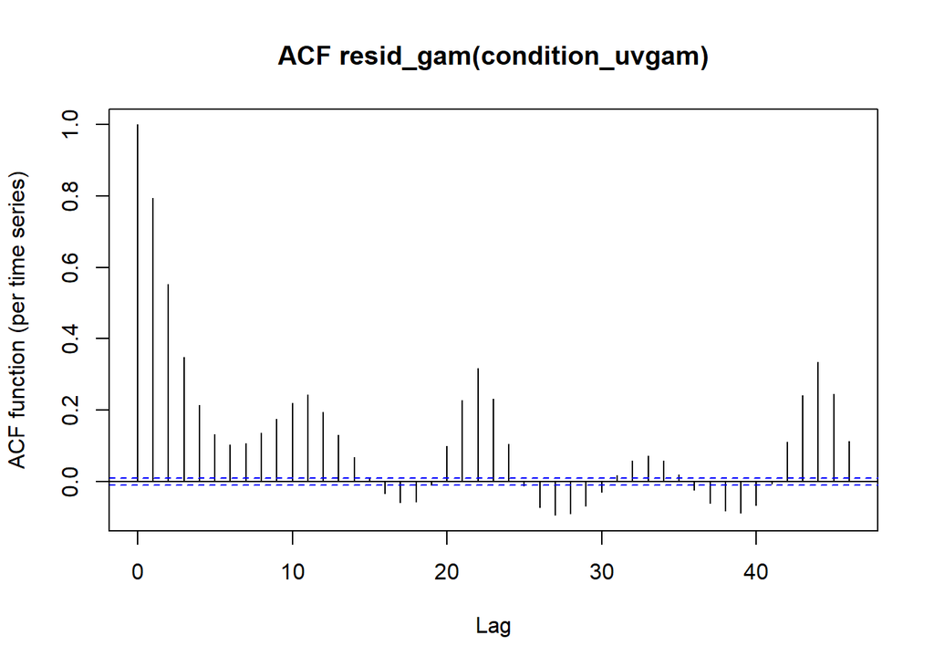

```r
uvular_static_long_cond <- uvular_static %>%
  pivot_longer(c(x_mean_z, y_mean_z), names_to = "dimension", values_to = "position") %>%
  mutate(stress.cond = factor(paste0(stress,".",type))) %>%
  mutate(stress.cond.dim = factor(paste0(stress.cond,".",dimension))) %>%
  arrange(clip_id, stress.cond.dim, knot) %>% select(-c("x_mean", "y_mean"))

condition_uvgam <- bam(position ~ stress.cond.dim + s(knot, by = stress.cond.dim),
                    data = uvular_static_long_cond,
                    family = "scat",
                    discrete = T)
AR1.rho <- acf_resid(condition_uvgam)[2]
```

```r
condition_uvgam <- bam(position ~ stress.cond.dim + s(knot, by = stress.cond.dim),
                    data = uvular_static_long_cond,
                    rho = AR1.rho,
                    AR.start = uvular_static_long_cond %>% pull(knot) == 0,
                    family = "scat",
                    discrete = T)

summary(condition_uvgam)
```

```
Family: Scaled t(6.54,0.136)
Link function: identity

Formula:
position ~ stress.cond.dim + s(knot, by = stress.cond.dim)

Parametric coefficients:
                                                      Estimate Std. Error
(Intercept)                                          0.0133719  0.0041011
stress.cond.dimstressed.consonantcluster.y_mean_z    0.0051556  0.0057998
stress.cond.dimstressed.sylinitial.x_mean_z         -0.0395453  0.0127774
stress.cond.dimstressed.sylinitial.y_mean_z         -0.0370961  0.0127775
stress.cond.dimstressed.wordinitial.x_mean_z        -0.0006997  0.0076121
stress.cond.dimstressed.wordinitial.y_mean_z        -0.0024724  0.0076121
stress.cond.dimunstressed.consonantcluster.x_mean_z -0.0025386  0.0059057
stress.cond.dimunstressed.consonantcluster.y_mean_z  0.0060540  0.0059057
stress.cond.dimunstressed.sylinitial.x_mean_z       -0.0159736  0.0129932
stress.cond.dimunstressed.sylinitial.y_mean_z       -0.0350857  0.0129933
stress.cond.dimunstressed.wordinitial.x_mean_z       0.0166517  0.0081765
stress.cond.dimunstressed.wordinitial.y_mean_z       0.0184012  0.0081765
                                                    t value Pr(>|t|)
(Intercept)                                           3.261  0.00111 **
stress.cond.dimstressed.consonantcluster.y_mean_z     0.889  0.37405
stress.cond.dimstressed.sylinitial.x_mean_z          -3.095  0.00197 **
stress.cond.dimstressed.sylinitial.y_mean_z          -2.903  0.00370 **
stress.cond.dimstressed.wordinitial.x_mean_z         -0.092  0.92676
stress.cond.dimstressed.wordinitial.y_mean_z         -0.325  0.74534
stress.cond.dimunstressed.consonantcluster.x_mean_z  -0.430  0.66730
stress.cond.dimunstressed.consonantcluster.y_mean_z   1.025  0.30532
stress.cond.dimunstressed.sylinitial.x_mean_z        -1.229  0.21894
stress.cond.dimunstressed.sylinitial.y_mean_z        -2.700  0.00693 **
stress.cond.dimunstressed.wordinitial.x_mean_z        2.037  0.04170 *
stress.cond.dimunstressed.wordinitial.y_mean_z        2.250  0.02442 *
---
Signif. codes:  0 '***' 0.001 '**' 0.01 '*' 0.05 '.' 0.1 ' ' 1

Approximate significance of smooth terms:
                                                              edf Ref.df     F
s(knot):stress.cond.dimstressed.consonantcluster.x_mean_z   8.988  9.000 17058
s(knot):stress.cond.dimstressed.consonantcluster.y_mean_z   8.990  9.000 28232
```

[output cut: 13 more lines]

```
s(knot):stress.cond.dimstressed.sylinitial.x_mean_z          <2e-16 ***
s(knot):stress.cond.dimstressed.sylinitial.y_mean_z          <2e-16 ***
s(knot):stress.cond.dimstressed.wordinitial.x_mean_z         <2e-16 ***
s(knot):stress.cond.dimstressed.wordinitial.y_mean_z         <2e-16 ***
s(knot):stress.cond.dimunstressed.consonantcluster.x_mean_z  <2e-16 ***
s(knot):stress.cond.dimunstressed.consonantcluster.y_mean_z  <2e-16 ***
s(knot):stress.cond.dimunstressed.sylinitial.x_mean_z        <2e-16 ***
s(knot):stress.cond.dimunstressed.sylinitial.y_mean_z        <2e-16 ***
s(knot):stress.cond.dimunstressed.wordinitial.x_mean_z       <2e-16 ***
s(knot):stress.cond.dimunstressed.wordinitial.y_mean_z       <2e-16 ***
---
Signif. codes:  0 '***' 0.001 '**' 0.01 '*' 0.05 '.' 0.1 ' ' 1

R-sq.(adj) =  0.973   Deviance explained =   90%
fREML =  49884  Scale est. = 1         n = 45584
```

Predict the tongue contours from the GAMM:

```r
condition_uvgam_frame <- expand_grid(
  knot = 0:10,
  stress.cond.dim = uvular_static_long_cond$stress.cond.dim %>% levels()
)
```

```r
condition_uvgam_predict <- predict(condition_uvgam, condition_uvgam_frame, se.fit = T) %>%
  as.data.frame() %>% as_tibble() %>% bind_cols(condition_uvgam_frame) %>% separate_wider_delim(stress.cond.dim, ".", names = c("stress", "condition", "dimension")) %>%
  pivot_wider(names_from = dimension, values_from = c("fit", "se.fit"))

colnames(condition_uvgam_predict) <- c("knot", "stress", "condition", "x_mean_z", "y_mean_z", "x_mean_z_se", "y_mean_z_se")
```

```r
condition_uvgam_pred_plot <- condition_uvgam_predict %>% ggplot() +
  aes(x_mean_z, y_mean_z, group = stress, color = stress) +
  geom_path() +
  geom_errorbarh(aes(xmin = x_mean_z - 1.96 * x_mean_z_se, xmax = x_mean_z + 1.96 * x_mean_z_se), alpha = 0.5) +
  geom_errorbar(aes(ymin = y_mean_z - 1.96 * y_mean_z_se, ymax = y_mean_z + 1.96 * y_mean_z_se), alpha = 0.5) +
  coord_fixed() +
  facet_wrap(vars(condition), ncol = 2) +
  theme(legend.position = "bottom")
```

UV-GAM: stressed vs unstressed uvular rhotics in different conditions (wordinitial, syllableinitial, consonantcluster)

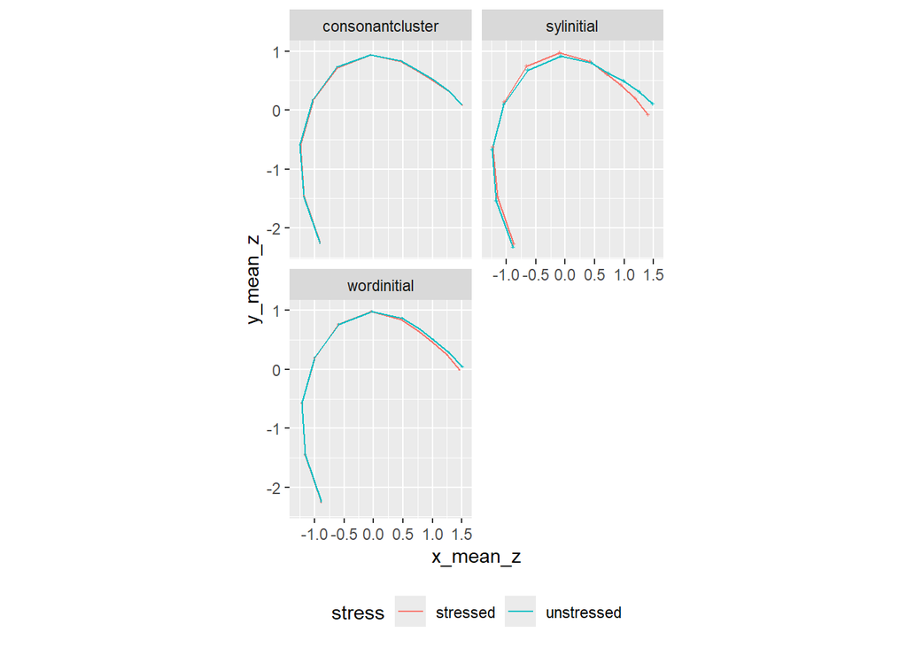

```r
condition_uvgam_pred_plot
```

–> much larger difference between rhotics in stressed and unstressed position in syllable-initial rhotics than in rhotics in other conditions.

**Question: Can I just add more categories to the model like I did here or do I have to add them separately first before making an interaction term?**

e.g.:

`bam(position ~ stress.cond.dim + s(knot, by = stress.cond.dim))` vs `bam(position ~ stress.cond.dim + s(knot, by = stress.dim) + s(knot, by = cond)` and then compare those two, e.g. with `compareML`?

## 1.4 adding more factor smooths?

Another question I had was if it is possible to add multiple factor smooths, additionally to the `participant` variable. For example, the tongue position might differ depending on the surrounding sounds, e.g., if the following vowel is a back vowel (o/u/…), a front vowel (i/e/…) or an /a/.

When I just add **s(knot, factor(vowel_cat), by = stress, bs = “fs”, m = 1)** to the MV GAMM in Section 1.1.2 it doesn’t work at all and I just get this error message:

```r
uvular_static$vowel_cat <- as.factor(uvular_static$vowel_cat)
uvular_static$participant <- as.factor(uvular_static$participant)

vow_mvgam_fs <- mgcv::gam(list(
    x_mean_z ~ stress +
      s(knot, by = stress, k = 5) +
      s(knot, participant, by = stress, bs = "fs", m = 1) + # participant as a factor smooth as in Coretta (2025)
      s(knot, vowel_cat, by = stress, bs = "fs", m = 1), # vowel as an additional factor smooth?
    y_mean_z ~ stress +
      s(knot, by = stress, k = 5) +
      s(knot, participant, by = stress, bs = "fs", m = 1) +
      s(knot, vowel_cat, by = stress, bs = "fs", m = 1)
  ),
  data = uvular_static,
  family = mvn(d = 2) # multivariate normal family, two dimensions
)
```

```
Error in -ll$lbb/norm(ll$lbb, "F") + Sb/norm(Sb, "F"): nicht passende Arrays
```

The UV GAMM works without the `by` variables from the factor smooths:

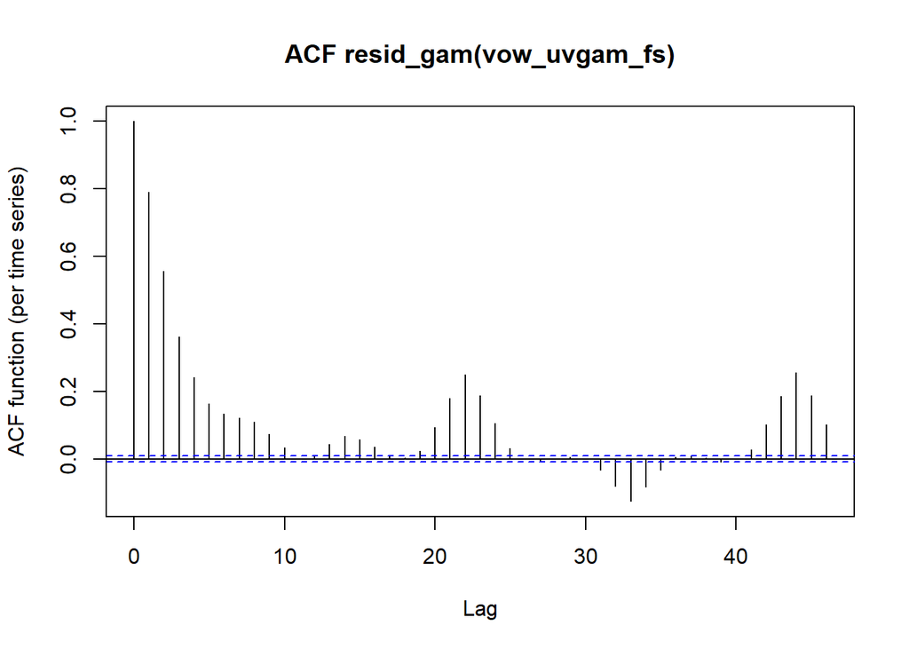

```r
uvular_static_long$vowel_cat <- as.factor(uvular_static_long$vowel_cat)
uvular_static_long$participant <- as.factor(uvular_static_long$participant)
vow_uvgam_fs <- bam(position ~ stress.dim +
                         s(knot, by = stress.dim) +
                         s(knot, participant, bs = "fs", m = 1) + # factor smooth for participant
                         s(knot, vowel_cat, bs = "fs", m = 1),
                    data = uvular_static_long,
                    family = "scat",
                    discrete = T)
AR1.rho <- acf_resid(vow_uvgam_fs)[2]
```

```r
vow_uvgam_fs <- bam(position ~ stress.dim +
                      s(knot, by = stress.dim) +
                      s(knot, participant, bs = "fs", m = 1) +
                      s(knot, vowel_cat, bs = "fs", m = 1),
                    data = uvular_static_long,
                    rho = AR1.rho,
                    AR.start = uvular_static_long %>% pull(knot) == 0,
                    family = "scat",
                    discrete = T)
summary(vow_uvgam_fs)
```

```
Family: Scaled t(5.338,0.108)
Link function: identity

Formula:
position ~ stress.dim + s(knot, by = stress.dim) + s(knot, participant,
    bs = "fs", m = 1) + s(knot, vowel_cat, bs = "fs", m = 1)

Parametric coefficients:
                                Estimate Std. Error t value Pr(>|t|)
(Intercept)                   -0.0073003  0.0416486  -0.175    0.861
stress.dimstressed.y_mean_z   -0.0046254  0.0037525  -1.233    0.218
stress.dimunstressed.x_mean_z  0.0006702  0.0038537   0.174    0.862
stress.dimunstressed.y_mean_z -0.0046614  0.0038537  -1.210    0.226

Approximate significance of smooth terms:
                                         edf Ref.df         F p-value
s(knot):stress.dimstressed.x_mean_z    8.747  8.762     137.1  <2e-16 ***
s(knot):stress.dimstressed.y_mean_z    8.824  8.834     252.3  <2e-16 ***
s(knot):stress.dimunstressed.x_mean_z  8.745  8.760     139.9  <2e-16 ***
s(knot):stress.dimunstressed.y_mean_z  8.822  8.832     250.4  <2e-16 ***
s(knot,participant)                   61.937 71.000 8552475.4  <2e-16 ***
s(knot,vowel_cat)                     17.989 26.000 2246939.7  <2e-16 ***
---
Signif. codes:  0 '***' 0.001 '**' 0.01 '*' 0.05 '.' 0.1 ' ' 1

R-sq.(adj) =  0.981   Deviance explained = 90.2%
fREML =  51623  Scale est. = 1         n = 45584
```

Prediction:

```r
vow_uvgam_fs_frame <- expand_grid(
  knot = 0:10,
  stress.dim = uvular_static_long$stress.dim %>% levels(),
  participant = uvular_static_long$participant %>% levels(),
  vowel_cat = uvular_static_long$vowel_cat %>% levels()
)
```

```r
vow_uvgam_fs_predict <- predict(vow_uvgam_fs, vow_uvgam_fs_frame, se.fit = T) %>%
  as.data.frame() %>% as_tibble() %>%
  bind_cols(vow_uvgam_fs_frame) %>% separate_wider_delim(stress.dim, ".", names = c("stress", "dimension")) %>%
  pivot_wider(names_from = dimension, values_from = c("fit", "se.fit"))

colnames(vow_uvgam_fs_predict) <- c("knot", "stress", "participant", "vow_cat", "x_mean_z", "y_mean_z", "x_mean_z_se", "y_mean_z_se")
```

```r
vow_uvgam_fs_plot <- vow_uvgam_fs_predict %>% ggplot() +
  aes(x_mean_z, y_mean_z, group = stress, color = stress) +
  geom_path() + geom_errorbarh(aes(xmin = x_mean_z - 1.96 * x_mean_z_se, xmax = x_mean_z + 1.96 * x_mean_z_se), alpha = 0.5) +
  geom_errorbar(aes(ymin = y_mean_z - 1.96 * y_mean_z_se, ymax = y_mean_z + 1.96 * y_mean_z_se), alpha = 0.5) +
  facet_grid(participant ~ vow_cat) +
  coord_fixed() +
  theme(legend.position = "bottom")
```

UV-GAM: stressed vs unstressed uvular rhotics, two factor smooths: 1. over knot for participant, 2. over knot for vowel-category (front vowel/back vowel/a)

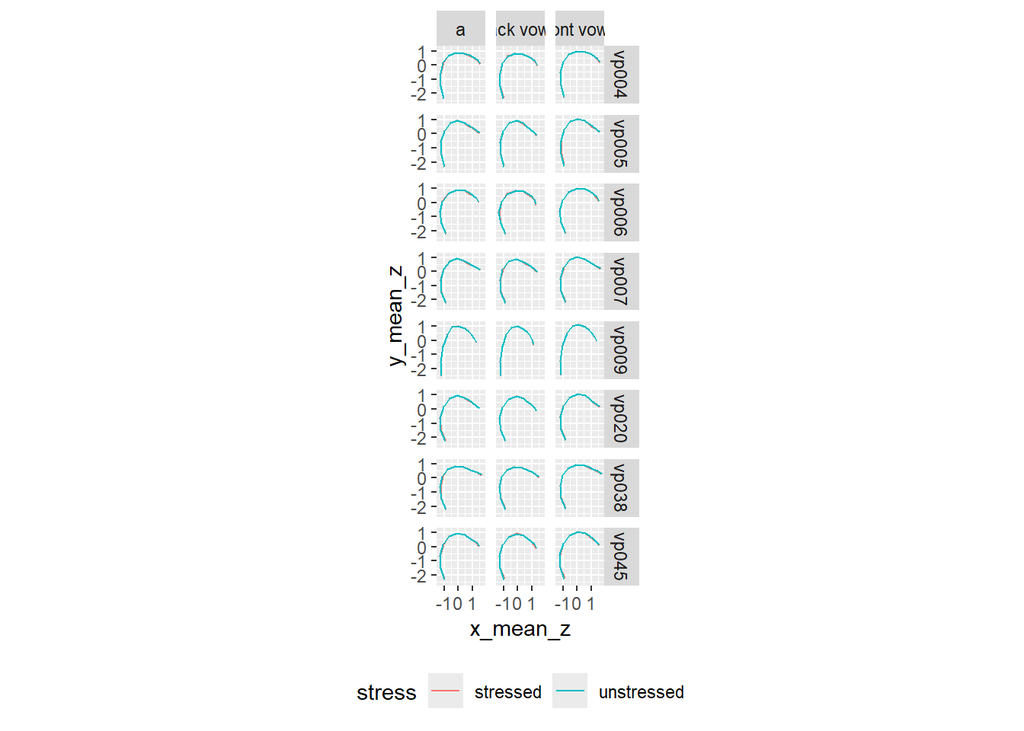

```r
vow_uvgam_fs_plot
```

Now, exclude the factor smooth from the prediction:

```r
excl <- c("s(knot,participant)", "s(knot,vowel_cat)")
```

```r
vow_uvgam_fs_predict2 <- predict(vow_uvgam_fs, vow_uvgam_fs_frame, se.fit = T, exclude = excl) %>%
  as.data.frame() %>% as_tibble() %>%
  bind_cols(vow_uvgam_fs_frame) %>% separate_wider_delim(stress.dim, ".", names = c("stress", "dimension")) %>%
  pivot_wider(names_from = dimension, values_from = c("fit", "se.fit"))

colnames(vow_uvgam_fs_predict2) <- c("knot", "stress", "participant", "vow_cat", "x_mean_z", "y_mean_z", "x_mean_z_se", "y_mean_z_se")
```

```r
vow_uvgam_fs_plot2 <- vow_uvgam_fs_predict2 %>% subset(participant == "vp004" & vow_cat == "a") %>% ggplot() +
  aes(x_mean_z, y_mean_z, group = stress, color = stress) +
  geom_path() + geom_errorbarh(aes(xmin = x_mean_z - 1.96 * x_mean_z_se, xmax = x_mean_z + 1.96 * x_mean_z_se), alpha = 0.5) +
  geom_errorbar(aes(ymin = y_mean_z - 1.96 * y_mean_z_se, ymax = y_mean_z + 1.96 * y_mean_z_se), alpha = 0.5) +
  coord_fixed() +
  theme(legend.position = "bottom")
```

UV-GAM: stressed vs unstressed uvular rhotics, excluded two factor smooths: 1. over knot for participant, 2. over knot for vowel-category (front vowel/back vowel/a)

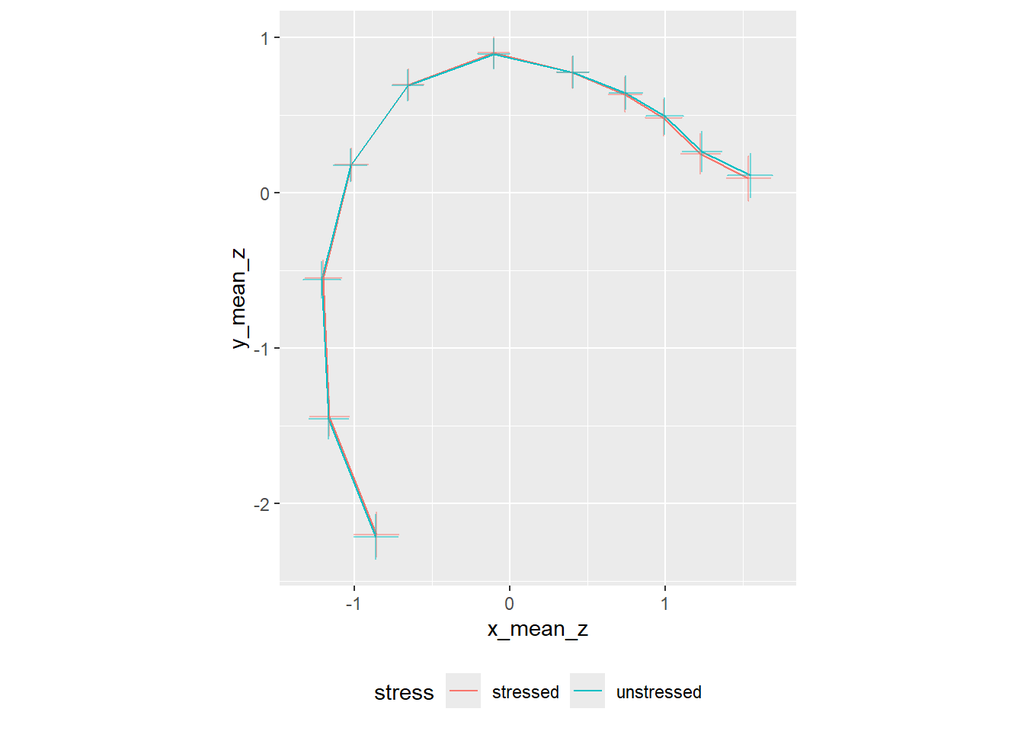

```r
vow_uvgam_fs_plot2
```

The difference between tongue contour of rhotics in stressed vs unstressed position nearly vanishes in this model, so maybe the initial difference we saw, is due to the distribution of following vowels instead of the stress.